# How to generate slides from a Jupyter notebook

# JupyterLab Cell tag editor

In order to export your notebooks as Reveal.js slides, follow these steps:

- Open a notebook by double clicking it in the file browser.
- Select Cell tools in the left sidebar.
- Select the slide type (Slide, Subslide, Fragment, Skip, Notes).

## Cell tag

[figure not shown]

# Type of slides

- **Slide**: New slide
- **Sub-Slides**: New section within a topic. Cells with this marker will be placed on a new slide underneath the previous slide.
- **Fragments**: Additional information that adds to an existing slide or sub-slide.
- **-**: additional information that appears at the same time than the previous cell.
- **Notes**: Speaker notes. These can be viewed on a separate browser window out of the view from the audience. (see the ‘Installation’ -> ‘Full Setup’ section of the REVEAL.js Github repo).
- **Skip**: Cells that are set to skip do not appear in the presentation.

# Generate your presentation

### Exporting Notebooks

JupyterLab allows you to export your jupyter notebook files (.ipynb) into other file formats. For creating slides, we can use:

- Reveal.js Slides .html

To access these options, while a notebook is open, browse the File menu:

[figure not shown]

# Customize your slides

## How to hide code to show cell output only?

- In the cell tool, click on "Advanced Tools" to edit metadata
- Paste the following in "Cell Metadata"

```
{
    "slideshow": {
        "slide_type": "fragment"
    },
    "tags": [
        "to_remove"
    ]
}
```

### Advanced cell editor

[figure not shown]

# Example Hide code and show outputs only

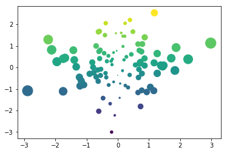

```python
import numpy as np
import matplotlib.pyplot as plt
%matplotlib inline
# Turn interactive mode on
plt.ion()

data = np.random.randn(2, 100)
fig, ax = plt.subplots()
ax.scatter(*data, c=data[1], s=100*np.abs(data[0]));
```

**Figure: scatterplot with random data**

# Generate your slides

- Create a new cell and execute the command:

```python
!jupyter nbconvert presentation.ipynb --to slides --no-prompt --TagRemovePreprocessor.remove_input_tags={\"to_remove\"}
```

```
[NbConvertApp] Converting notebook presentation.ipynb to slides
[NbConvertApp] Writing 323700 bytes to presentation.slides.html
```

- A new file was created. Its name is the same as your jupyter notebook but its extension is `html`.
- Double click on your file to show your presentation

# Visualize in slideshow mode

- Switch to standard jupyter notebook e.g. change `lab` to `tree` in the Jupyterhub address.

For instance, if you adress is

`https://abisko.uiogeo-apps.sigma2.no/user/df0bb829-8d2d-487e-9748-cf1b58c1ab4b/lab`

then the corresponding standard jupyter noteboo view is

`https://abisko.uiogeo-apps.sigma2.no/user/df0bb829-8d2d-487e-9748-cf1b58c1ab4b/tree`

- Click on your html file to visualize.

# Skip cells

You can hide cells, for instance to hide the generation of your slides.

- In the cell tool, select "Skip"

# Tips and ticks

- if you add images (not generated by python plotting), it is important to download these images too (for instance to the github repositoy).
- In presentation mode, you can know more about the reveal-specific shortcuts just pressing the help button at the slideshow left bottom corner.
- Darkish themes have css conflict with the notebook css, so it need customization to make them work (not provided by default).
- Markdown Images get left aligned by default. Enclose the image like `<center>![noimg](path/to/image.png)</center>` to center it.

# Customize the style of your slides

### Change the default theme

- By default `simple` theme is used
- Try out for instance `sky`

```python
!jupyter nbconvert presentation.ipynb --to slides --no-prompt --TagRemovePreprocessor.remove_input_tags={\"to_remove\"} --SlidesExporter.reveal_theme=sky
```

```
[NbConvertApp] Converting notebook presentation.ipynb to slides
[NbConvertApp] Writing 319216 bytes to presentation.slides.html
```

List of available theme at https://github.com/hakimel/reveal.js/tree/master/css/theme